# Linear least squares

### Background

- **Empirical mean**:
  $$\overline{X} = \frac{1}{n}\sum_{i=1}^{n}X_i$$
- **Empirical standard deviation**:
  $$S^2 = \frac{1}{n-1}\sum_{i=1}^{n}(X_i-\overline{X})^2$$
- **Centering**: If we subtract the mean from data points, we get data that has mean 0. This is called centering.
- **Scaling**: The data defined by $X_i/s$ have empirical standard deviation 1. This is called scaling.
- **Normalization**: the data defined by
  $$Z_i = \frac{X_i-\overline{X}}{s}$$
  have empirical mean zero and empirical standard deviation 1. This process is called normalization.
  - Normalized data are centered at 0 and have units equal to standard deviations of the original data.
- **Empirical covariance**: when we consider pairs of data, $(X_i, Y_i)$, the empirical covariance is
  $$Cov(X,Y)=\frac{1}{n-1}\sum_{i=1}^{n}(X_i-\overline{X})(Y_i-\overline{Y})=\frac{1}{n-1}(\sum_{i=1}^{n}X_iY_i-n\overline{X}\overline{Y})$$
- **Correlation**:
  $$Cor(X,Y)=\frac{Cov(X,Y)}{S_x S_y}$$
  where $S_x$ and $S_y$ are the estimates of standard deviations for the X observations and Y observations, respectively.
  - $Cor(X,Y)=Cor(Y,X)$
  - $-1 <=Cor(X,Y)<= 1$
  - $Cor(X,Y)=1$ and $Cor(X,Y)=-1$ only when X or Y observations fall perfectly on a positive or negative sloped line, respectively.
  - $Cor(X,Y)$ measures the strength of the linear relationship betwen X and Y data, with stronger relationship as $Cor(X,Y)$ heads towards -1 or 1.
  - $Cor(X,Y)=0$ implies no linear relationship.

### Linear Least Squares

Recall Galton dataset that has children and parents heights. Let’s say we want to use parents’ heights to explain children’s heights.

- Let $Y_i$ be the $i^{th}$ child’s height and $X_i$ be the $i^{th}$ parents’ heights.
- Consider finding the best line
  - Child’s height = $\beta_0$ + Parent’s Height$\beta_1$
- Use least squares
  $$\sum_{i=1}^{n}\{Y_i-(\beta_0+\beta_1 X_i)\}^2$$
- **Results**
  - The least squares model fit to the line $Y=\beta_0+\beta_1 X$ through the data pairs $(X_i, Y_i)$ with $Y_i$ as the outcome obtains the line $Y=\hat{\beta_0}+\hat{\beta_1}X$ where
    $$\hat{\beta_1} = Cor(Y,X)\frac{Sd(Y)}{Sd(X)}, \hat{\beta_0}=\overline{Y}-\hat{\beta_1}\overline{X}$$
  - $\hat{\beta_1}$ has the units of $Y/X$, and $\hat{\beta_0}$ has the units of $Y$.
  - The line passes through the point $(\overline{X},\overline{Y})$
  - The slope of the regression line with X as the outcome and Y as the predictor is $Cor(Y,X)Sd(X)/Sd(Y)$.
  - The slope is the same one you would get if you centered the data, $(X_i-\overline{X}, Y_i-\overline{Y})$, and did regression through the origin.
  - If you normalized the data ${\frac{X_i-\overline{X}}{Sd(X)},\frac{Y_i-\overline{Y}}{Sd(Y)}}$, the slope is $Cor(Y,X)$
- Coding example:

```r
data(galton)
y <- galton$child
x <- galton$parent
beta1 <- cor(y, x)*sd(x)/sd(y)
beta0 <- mean(y) -beta1*mean(x)
rbind(c(beta0, beta1), coef(lm(x~y)))
```

```
##      (Intercept)         y
## [1,]    45.84408 0.3256475
## [2,]    46.13535 0.3256475
```

```r
# Let's check if regresion through the origin yield an equivalent slope
yc <- y - mean(y)
xc <- x - mean(x)
#Equation for getting slope of regression through origin
beta1 <- sum(yc*xc)/sum(xc^2)
c(beta1, coef(lm(y~x))[2], coef(lm(yc~xc-1)))
```

```
##                   x        xc
## 0.6462906 0.6462906 0.6462906
```

```r
#Normalizing variables results in the slope being the correlation of X and Y
yn <- (y - mean(y))/sd(y)
xn <- (x - mean(x))/sd(x)
c(cor(y,x), cor(yn, xn), coef(lm(yn~ xn))[2])
```

```
##                            xn
## 0.4587624 0.4587624 0.4587624
```

### Regression to the mean

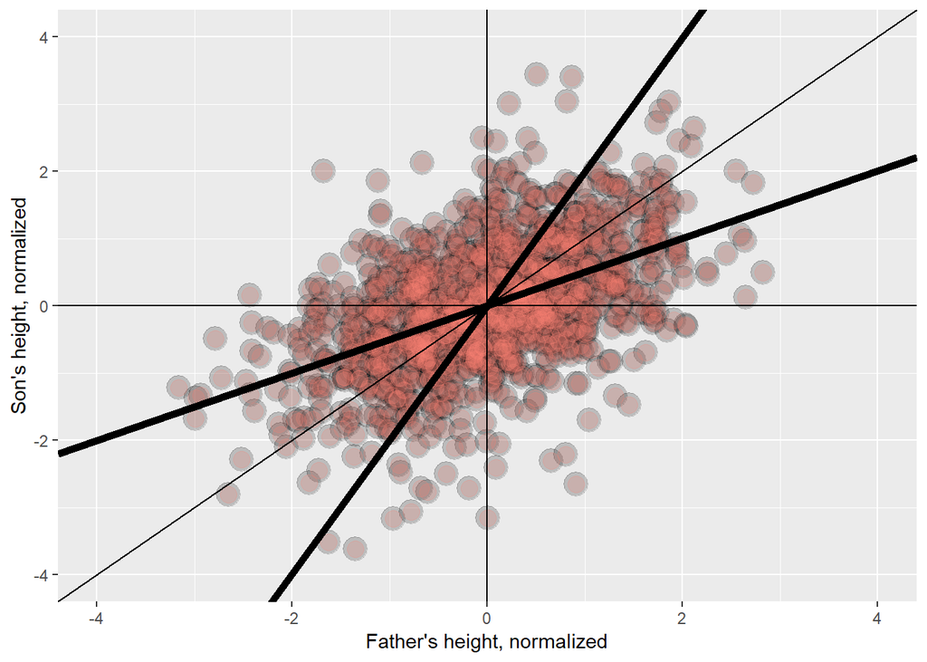

```r
data(father.son)
y <- (father.son$sheight - mean(father.son$sheight)) / sd(father.son$sheight)
x <- (father.son$fheight - mean(father.son$fheight)) / sd(father.son$fheight)
rho <- cor(x, y)
g <- ggplot(data.frame(x = x, y = y), aes(x = x, y = y))
g <- g + geom_point(size = 6, colour = "black", alpha = 0.2)
g <- g + geom_point(size = 4, colour = "salmon", alpha = 0.2)
g <- g + xlim(-4, 4) + ylim(-4, 4)
g <- g + geom_abline(intercept = 0, slope = 1)
g <- g + geom_vline(xintercept = 0)
g <- g + geom_hline(yintercept = 0)
g <- g + geom_abline(intercept = 0, slope = rho, size = 2)
g <- g + geom_abline(intercept = 0, slope = 1 / rho, size = 2)
g <- g + xlab("Father's height, normalized")
g <- g + ylab("Son's height, normalized")
g
```

The fact that regression line is closer to x-axis demonstrates the regression to the mean. The x-axis is the mean of the son’s height. We can observe the same when we flip the dependent/independent variables.